# Cnidarian hair cell development illuminates an ancient role for the class IV POU transcription factor in defining mechanoreceptor identity

# RNA-seq

First we must sort and count the alignments made by STAR. For this, we use HTseq and samtools. In terminal, we run

```bash
cd alignment
#@ run for each replicate
# To compress file to bam
samtools view -S -b alignment/Nematostella_vectensis_CH2_12d_POU-+_wild_rep1.out.sam > Nvect_POU-+_rep1_Aligned.bam
# Sort
samtools sort Nvect_POU-+_rep1_Aligned.bam -o Nvect_POU-+_rep1_sorted.bam
# Counts
htseq-count -f bam -s yes -r pos Nvect_POU-+_rep1_sorted.bam ../ref_genomes/[nveGenes.vienna130208.nemVec1.gtf] > POU-+_rep1.counts
#@ run for each replicate
```

Finally, merge the readings into a single count table.

```bash
cd alignment
paste POU--_rep*.counts POU-+_rep*.counts > counts_table_DGE.txt
```

I then used R to load the data. First, I read the DGE results

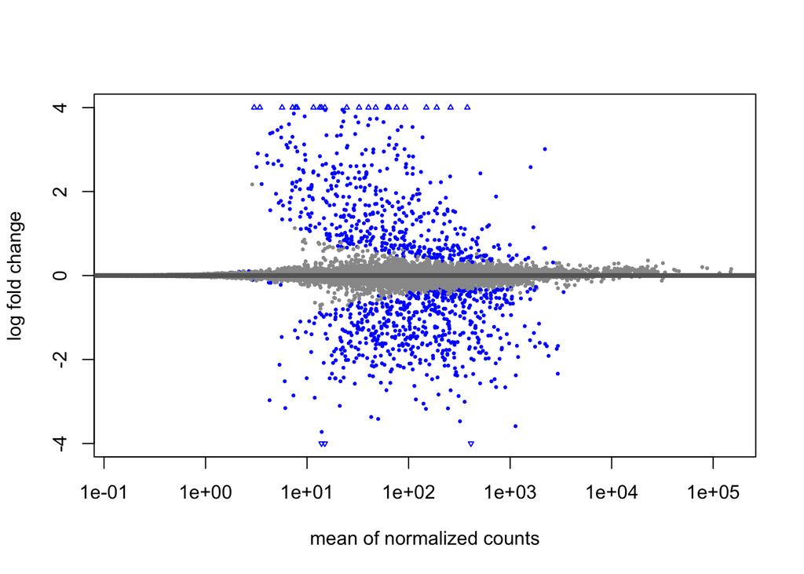

```r
library(DESeq2)
library(apeglm)
#Read data
data.dge <- read.delim(file = '../alignment/counts_table_DGE.txt',sep = '\t', header = F, row.names = 1)
#Assign names
condition <- factor(c("POU_ko","POU_ko","POU_ko","POU_ko","POU_wt","POU_wt","POU_wt","POU_wt"), levels = c('POU_wt','POU_ko'))
colData <- data.frame(row.names=colnames(data.dge), condition)

dds <- DESeqDataSetFromMatrix(countData = data.dge,
                              colData = colData,
                              design = ~ condition )

#Erase data with no counts
dds <- dds[ rowSums(counts(dds)) > 1, ]
dds <- DESeq(dds)
res <- results(dds)

#You can preprocces all again, and you should get this figure
resLFC <- lfcShrink(dds, coef=2, type="apeglm")
plotMA(resLFC, ylim=c(-4,4))
```

In addition, we can perform a principal component analysis on the results using the following.

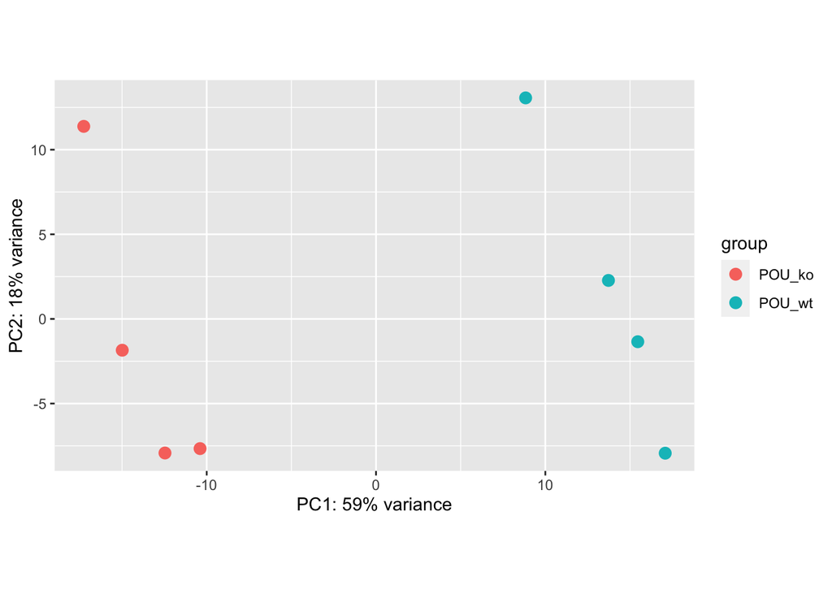

```r
library(reshape)
library(SummarizedExperiment)
vst <- varianceStabilizingTransformation(dds)
vst@colData@listData[["condition"]] <- c("POU_ko","POU_ko","POU_ko","POU_ko","POU_wt","POU_wt","POU_wt","POU_wt")
plotPCA(vst, intgroup = "condition")
```

If we want to confirm the numbers from downregulated and upregulated genes with different p values

```r
#Para 0.05
nrow(data.frame(resLFC@rownames[resLFC@listData[["pvalue"]] <0.05]))
```

```
## [1] 1920
```

```r
#Para 0.01
nrow(data.frame(resLFC@rownames[resLFC@listData[["pvalue"]] <0.01]))
```

```
## [1] 1249
```

Then, to list the downregulated and upregulated genes

```r
#Keep only p-value<0.01
differential_genes <- data.frame(resLFC@rownames[resLFC@listData[["pvalue"]] <0.01])
#Add column name
colnames(differential_genes) <- c('gene')
#Add Fold change
differential_genes$fold_change <- resLFC@listData[["log2FoldChange"]][resLFC@listData[["pvalue"]] <0.01]
#Add base mean
differential_genes$mean_counts <- resLFC@listData[["baseMean"]][resLFC@listData[["pvalue"]] <0.01]
#Add p value
differential_genes$pvalue <- resLFC@listData[["pvalue"]][resLFC@listData[["pvalue"]] <0.01]
# Eliminate empty rows
differential_genes <- differential_genes[complete.cases(differential_genes),]
```

From the annotation data we previously downloaded, we have nveGenes.vienna130208.GO_annotation_141017.txt which listed the genes with its GO terms. It is usefull to read this in R. Also, it is useful to have the p-values of the DGE in this dataframe because they can be used as scores for Gene ontology enrichment.

```r
#Read file
GO_terms <- read.delim(file = '../data/nveGenes.vienna130208.GO_annotation_141017.txt',sep = '\t', header = F)
# Extract those that are differentially expressed
GO_terms_differential_expressed <- GO_terms[GO_terms$V1%in%differential_genes$gene, ]
#Quiero tener los valores de p, guardados en differential_genes$pvalue en el df de GO
for(j in 1:nrow(GO_terms_differential_expressed)) {
  for(k in 1:nrow(differential_genes)) {
     if (GO_terms_differential_expressed$V1[j] == differential_genes$gene[k]) {
         GO_terms_differential_expressed$pvalue[j] <- differential_genes$pvalue[k]
     }
    k <- k+1
  }
  j<- j+1
  }
```

```r
#reading table
equival <- read.delim(file = '../data/equivalence_table.tsv',sep = '\t', header = F)
###Loop for extracting data
differential_genes$JGI_ID <- 'No data'
j <-1
k<-1

for(j in 1:nrow(differential_genes)) {
  for(k in 1:nrow(equival)) {
     if (differential_genes$gene[j] == equival$V1[k]) {
         differential_genes$JGI_ID[j] <- equival$V3[k]
     }
    k <- k+1
  }
  j<- j+1
}


upregulated_genes <- differential_genes[differential_genes$fold_change>0,]
downregulated_genes <- differential_genes[differential_genes$fold_change<0,]
```

Now that I have this data, I can perform a GO enrichment analysis.

```r
library(rrvgo)
library(org.Ce.eg.db) #C. elegans data as reference
library(clusterProfiler)
#We need some dfs to do the job

#Getting terms to gene dataframe
GOterms_to_genes <- GOterms_to_genes[,c(3,1)]
colnames(GOterms_to_genes) <- c('term','gene')
#Getting term to name df
GOterms_to_names <- GOterms_to_names[,c(3,4)]
colnames(GOterms_to_names) <- c('term','name')

#GO enrichment for downregulated genes
ggo <- enricher(
  downregulated_genes$gene,
  pvalueCutoff = 0.05,
  pAdjustMethod = "BH",
  TERM2GENE=GOterms_to_genes,
  TERM2NAME = GOterms_to_names
)

#GO enrichment result
ggo_result <- ggo@result
#Filtering GO enrichment result
ggo_result <- ggo_result[ggo_result$p.adjust<0.05,]

#Generating matrix to plot
simMatrix <- calculateSimMatrix(ggo_result$ID,
                                orgdb="org.Ce.eg.db",
                                ont="BP",
                                method="Rel")

GO_terms_names <- ggo_result[ggo_result$ID%in%row.names(simMatrix),]
scores <- setNames(-log10(GO_terms_names$p.adjust), GO_terms_names$ID)
#Reducing dimensions to plot
reducedTerms <- reduceSimMatrix(simMatrix, scores,
                                orgdb="org.Ce.eg.db", threshold = 0.8)
treemapPlot(reducedTerms)
```

Using the above code, we should produce a figure like the following one

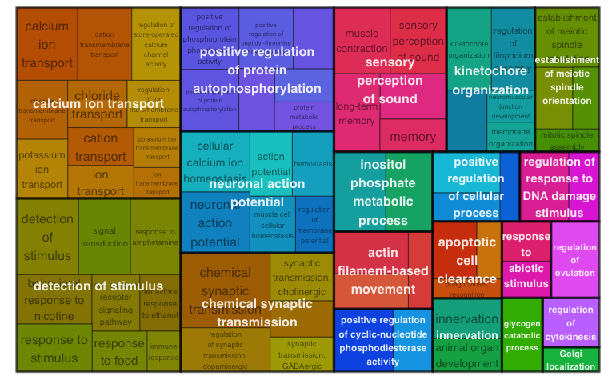

TreeMap of representative GO terms in downregulated genes

# ChIP-seq analysis

ChIP-seq technique was used to obtain target gene sequences of the transcription factor POU-IV. We used Macs2 software to perform the peak calling of the reads.

```bash
macs2 callpeak -t data/[ChIPseq_rep1] -c data/[ChIPseq_rep1_input] -f BAMPE -g 361523379 -n cp -B
```

```bash
# Code used to obtain consensus peaks.
[path_to_mspc]/mspc -i data/*.narrowPeak -r tec -w 1e-4 -s 1e-8 -o ./MSPC_outdir
```

Subsequently, bedtools get fasta was used to obtain the fasta sequences to be analyzed in Rsat. For this we use the following code.

```bash
bedtools getfasta -fi ../ref_genomes/Nvectensis.fa -bed MSPC_outdir/ConsensusPeaks.bed -fo consensus_peaks_sequence
```

This file can be uploaded in http://rsat.sb-roscoff.fr/peak-motifs_form.cgi with the option local-word-analysis in motif discovery parameters. The results were downloaded and uploaded to Tomtom against the Jaspar database.

Results can be found in the following table

Motif

Number of peaks with at least one predicted site

Mean of predicted sites per peak

Jaspar non-redundant database hits wit cor value

E-value

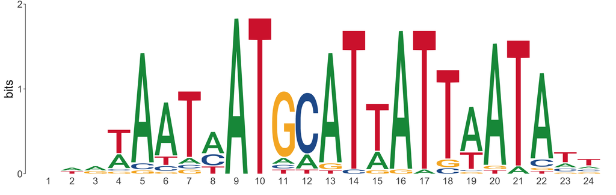

724 (5.58%)

1.23

-POU4F3 (0.845 )  
-POU4F2 (0.779)  
-POU4F1 (0.870)

5.2e-75

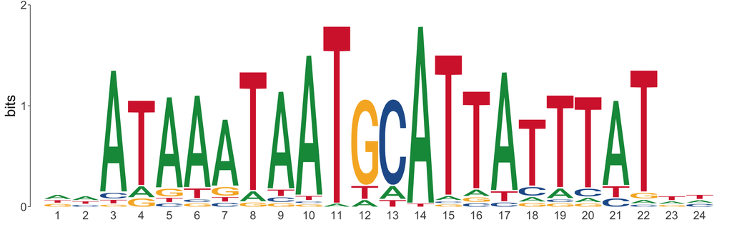

429 (3.31%)

2.16

-POU4F3 (0.818)  
-POU4F1 (0.829)  
-POU4F2 (0.734)

1.2e-52

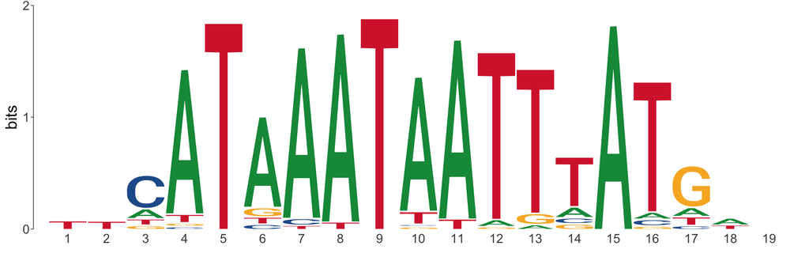

1892 (14.54%)

1.60

-POU4F3 (0.840)  
-POU4F1 (0.736)  
-POU4F2 (0.842)

4.8e-36